# **Descoberta de Padrões Recorrentes de Mercado através de Análise Simbólica de Séries Temporais**

## **Um estudo com base em SAX sobre cotações semanais de futuros de obrigações do tesouro dos EUA (1980–2026)**

#### Autor: Luis Rito Filipe

#### Junho de 2026

⚠️ **Aviso Importante:** Este relatório apresenta um estudo quantitativo do histórico de padrões recorrentes de preços e o seu comportamento subsequente. Não constitui aconselhamento de investimento. Por favor, leia a Declaração de Exclusão de Responsabilidade no final da página.

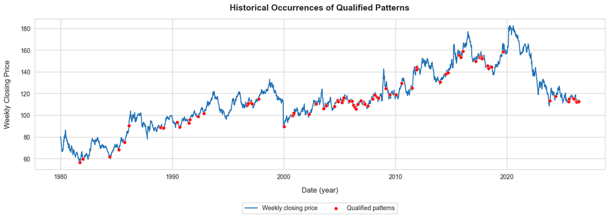

# Sobre o Estudo

Este estudo explora a deteção de padrões recorrentes de mercado através da Análise Simbólica de Séries Temporais, com especial ênfase no método Symbolic Aggregate approXimation (SAX). O principal objetivo consiste em identificar padrões recorrentes de preços em séries temporais de instrumentos financeiros que possam conter informação preditiva sobre a trajetória futura dos preços.

As experiências são realizadas sobre contratos de futuros de Obrigações do Tesouro dos Estados Unidos a 30 anos, um instrumento financeiro negociado na Chicago Board of Trade. Esta escolha é motivada pelas características estatísticas e comportamentais distintas dos instrumentos de rendimento fixo quando comparados com outras classes de ativos financeiros.

O objetivo global desta investigação não é desenvolver um sistema de negociação autónomo, mas sim identificar estruturas simbólicas recorrentes que, quando combinadas com sinais ou filtros adicionais, possam contribuir para o apoio à tomada de decisões de investimento de médio prazo.

Está disponível **[outra versão desta publicação](https://luisritofilipe.github.io/data_science_learning/Discovering_recurring_market_patterns_with_symbolic_time_series_analysis_with_code.html)**, que inclui o código Python utilizado na análise. A presente versão concentra-se na metodologia, nos resultados e na interpretação, omitindo excertos de código para melhorar a legibilidade e a apresentação visual.

# Sumário

Este estudo investiga a aplicação do método Symbolic Aggregate Approximation (SAX) na identificação de padrões recorrentes de preços em séries temporais semanais de futuros de Obrigações do Tesouro. As janelas históricas de preços foram normalizadas para eliminar a influência dos níveis absolutos de preço e transformadas em representações simbólicas, permitindo agrupar e analisar configurações de mercado estruturalmente semelhantes ao longo de mais de quatro décadas do histórico de cotações.

Para cada padrão recorrente, o comportamento subsequente dos preços a 3, 10 e 52 semanas foi avaliado através das estatísticas de valorização máxima (maximum run-up) e desvalorização máxima (minimum drawdown). Os padrões foram depois filtrados de acordo com critérios predefinidos de relação retorno/risco, concebidos para identificar configurações de mercado historicamente favoráveis, tendo simultaneamente em consideração a reduzida recorrência dos padrões individuais. A relevância histórica dos padrões selecionados foi posteriormente avaliada através de simulações de Monte Carlo, comparando o seu desempenho subsequente com pontos de entrada no mercado selecionados aleatoriamente.

Os resultados indicam que, embora a maioria dos padrões simbólicos seja única ou ocorra apenas um número reduzido de vezes, existe um subconjunto limitado que se repete com frequência suficiente para apresentar características historicamente favoráveis em termos de relação retorno/risco. Estes padrões qualificados foram observados predominantemente nas proximidades de inversões de tendências descendentes relevantes e durante fases de correção ligeira no decorrer de tendências ascendentes médio e longo prazo, tendo demonstrado uma valorização subsequente significativamente superior e desvalorizações máximas significativamente mais reduzidas do que seria expectável para entradas aleatórias no mercado.

Os resultados sugerem que as representações simbólicas de séries temporais de instrumentos financeiros permitem identificar configurações estruturais recorrentes de mercado que contêm informação histórica útil sobre o comportamento subsequente dos preços. Embora a metodologia não tenha como objetivo prever preços futuros nem constitua um sistema de negociação, fornece um enquadramento sistemático para reconhecer estados de mercado historicamente recorrentes que podem apoiar a investigação quantitativa e a tomada de decisões de investimento.

# Sobre o Conjunto de Dados

O conjunto de dados utilizado neste estudo é constituído por dados históricos diários do instrumento financeiro analisado. Inclui todo o histórico de cotações diárias disponível desde a sua criação, abrangendo a data, as cotações de abertura, máximo, mínimo e fecho. Embora o conjunto de dados seja disponibilizado pelo autor, dados equivalentes podem ser obtidos a partir de fontes públicas de dados financeiros e de fornecedores de dados de mercado.

# Metodologia

- Pré-processamento de Dados
- Construção de Janelas Deslizantes
- Transformação Simbólica (SAX)
- Análise e Filtragem de Padrões
- Resultados
- Implementação Prática
- Discussão
- Conclusões

# Pré-processamento de Dados

O estudo começa por transformar as cotações diárias em observações semanais. O objetivo consiste em identificar padrões recorrentes de preços que possam conter informação preditiva sobre o comportamento do mercado no médio prazo. Foram realizadas experiências iniciais utilizando tanto dados diários como semanais. Embora os dados diários tenham produzido um maior número de padrões recorrentes, os sinais obtidos apresentaram, de um modo geral, características de risco-retorno menos favoráveis. Os dados semanais geraram um menor número de ocorrências de padrões, mas produziram perfis de valorização máxima (maximum run-up) e desvalorização máxima (minimum drawdown) mais consistentes e passíveis de utilização prática. Por este motivo, as observações semanais foram selecionadas para o restante da análise.

|  | Date | Open | High | Low | Close |
| --- | --- | --- | --- | --- | --- |
| 0 | 1979-12-31 | 81.81000 | 82.530 | 80.00000 | 80.12000 |
| 1 | 1980-01-07 | 79.59000 | 81.120 | 79.44000 | 79.91000 |
| 2 | 1980-01-14 | 79.84000 | 80.310 | 77.91000 | 78.16000 |
| 2424 | 2026-06-15 | 112.71875 | 113.875 | 112.34375 | 113.37500 |
| 2425 | 2026-06-22 | 113.40625 | 114.625 | 112.50000 | 114.15625 |
| 2426 | 2026-06-29 | 114.09375 | 114.375 | 112.75000 | 112.78125 |

# Construção de Janelas Deslizantes

O passo seguinte consistiu na construção de janelas deslizantes a partir das cotações semanais de fecho. Para cada observação, foram selecionadas as cotações de fecho das últimas oito semanas para formar uma janela de comprimento fixo representativa do comportamento recente do mercado. Durante a fase exploratória do estudo foram avaliadas várias combinações entre o comprimento da janela e o número de intervalos (bins) utilizados pelo algoritmo SAX. Uma janela com oito observações e quatro intervalos proporcionou o melhor compromisso entre a recorrência dos padrões e a sua capacidade discriminativa, tendo, por isso, sido selecionada para a análise final.

Antes da aplicação do algoritmo SAX, cada janela de dados foi normalizada para eliminar a influência do nível absoluto dos preços. Esta normalização foi realizada dividindo todas as observações da janela pela primeira observação e subtraindo uma unidade aos valores obtidos. Como resultado, cada janela descreve a evolução relativa dos preços a partir do seu ponto inicial, em vez do nível absoluto de preços em que o padrão ocorreu. Isto permite que estruturas de preços semelhantes, ocorridas em diferentes níveis de preço, sejam representadas de forma idêntica. A tabela seguinte apresenta, a título de exemplo, as dez primeiras janelas de dados normalizadas.

|  | 0 | 1 | 2 | 3 | 4 | 5 | 6 | 7 |
| --- | --- | --- | --- | --- | --- | --- | --- | --- |
| 0 | 0.0 | -0.002621 | -0.024463 | -0.063155 | -0.078757 | -0.108337 | -0.147404 | -0.171118 |
| 1 | 0.0 | -0.021900 | -0.060693 | -0.076336 | -0.105994 | -0.145163 | -0.168940 | -0.145539 |
| 2 | 0.0 | -0.039662 | -0.055655 | -0.085977 | -0.126024 | -0.150333 | -0.126407 | -0.150333 |
| 3 | 0.0 | -0.016653 | -0.048228 | -0.089928 | -0.115241 | -0.090328 | -0.115241 | -0.093658 |
| 4 | 0.0 | -0.032109 | -0.074516 | -0.100257 | -0.074922 | -0.100257 | -0.078309 | -0.074922 |
| 5 | 0.0 | -0.043813 | -0.070409 | -0.044233 | -0.070409 | -0.047732 | -0.044233 | -0.049832 |
| 6 | 0.0 | -0.027814 | -0.000439 | -0.027814 | -0.004099 | -0.000439 | -0.006295 | 0.015078 |
| 7 | 0.0 | 0.028158 | 0.000000 | 0.024394 | 0.028158 | 0.022135 | 0.044120 | 0.110977 |
| 8 | 0.0 | -0.027387 | -0.003661 | 0.000000 | -0.005858 | 0.015524 | 0.080551 | 0.124048 |
| 9 | 0.0 | 0.024394 | 0.028158 | 0.022135 | 0.044120 | 0.110977 | 0.155699 | 0.135070 |

# Transformação Simbólica (SAX)

As janelas normalizadas foram depois transformadas utilizando o algoritmo Symbolic Aggregate Approximation (SAX). O SAX converte uma série temporal numérica numa sequência de símbolos, dividindo os valores normalizados por um número predefinido de intervalos (bins). Neste estudo foram utilizados quatro intervalos, originando uma palavra simbólica que representa a forma de cada trajetória de preços ao longo de oito semanas. Deste modo, janelas que apresentam comportamentos de preços semelhantes são mapeadas para a mesma representação simbólica, permitindo identificar padrões recorrentes em todo o conjunto de dados histórico.

A tabela seguinte apresenta, a título de exemplo, as dez primeiras palavras geradas pelo algoritmo SAX.

| 0 | 1 | 2 | 3 | 4 | 5 | 6 | 7 | 8 | 9 |
| --- | --- | --- | --- | --- | --- | --- | --- | --- | --- |
| ddccbbaa | ddccbbaa | ddccbaba | ddccabab | ddcababb | ddacabcb | dacabcbd | acabcbdd | babbacdd | abbaccdd |

# Análise e Filtragem de Padrões

Cada sequência simbólica produzida pelo algoritmo SAX foi concatenada numa palavra simbólica representativa de um padrão de preços único. As ocorrências de padrões que partilhavam a mesma representação simbólica foram agrupadas, permitindo identificar estruturas de preços recorrentes ao longo de todo o conjunto de dados histórico.

Considera-se que cada padrão é identificado no fecho da última observação da janela deslizante. As métricas de desempenho futuro são calculadas a partir da observação seguinte, garantindo que a representação simbólica é construída exclusivamente com base na informação que estaria disponível quando o padrão ocorreu.

Para avaliar o comportamento histórico subsequente a cada ocorrência de um padrão, foram calculadas métricas de desempenho futuro para horizontes de 3, 10 e 52 semanas. Para cada ocorrência, foram calculadas a valorização máxima futura (maximum run-up) e a desvalorização máxima futura (minimum drawdown), utilizando, respetivamente, os preços máximos e mínimos observados no período subsequente. Estas métricas quantificam os maiores movimentos favoráveis e desfavoráveis dos preços observados após a deteção de cada padrão.

As métricas de desempenho futuro foram posteriormente agregadas por padrão. Para cada padrão recorrente, foram calculadas estatísticas que incluem o número de ocorrências, a mediana da valorização máxima, a desvalorização máxima e a desvalorização da cauda (Tail Drawdown). Para caracterizar o contexto de mercado predominante, foi calculado um percentil móvel da volatilidade. Em cada semana, a volatilidade anualizada das últimas 52 semanas foi expressa como a sua posição percentual relativamente às 52 observações semanais anteriores da volatilidade, fornecendo uma medida normalizada do regime de volatilidade em vigor. Por fim, foi aplicado um conjunto de restrições relativas ao risco e à recorrência para identificar padrões que, historicamente, antecederam valorizações favoráveis dos preços no médio prazo, mantendo simultaneamente um perfil de risco descendente aceitável.

Os mercados financeiros são intrinsecamente dinâmicos, e não é expectável que padrões que historicamente apresentaram características favoráveis continuem indefinidamente a satisfazer os mesmos critérios de desempenho. Por esta razão, o procedimento de seleção de padrões foi concebido para tolerar um número limitado de resultados históricos desfavoráveis, preservando simultaneamente um perfil de risco conservador.

Para padrões recorrentes com um número relativamente reduzido de ocorrências (entre três e nove), exigiu-se que as desvalorizações máximas históricas a 3 e a 52 semanas permanecessem acima de -3% e -10%, respetivamente. Este critério assegura que todas as ocorrências históricas destes padrões relativamente pouco frequentes satisfizeram os limites de risco previamente definidos.

Para padrões com dez ou mais ocorrências, foi adotado um critério menos restritivo, substituindo a desvalorização máxima histórica a 52 semanas pelo 10.º percentil da distribuição das desvalorizações máximas a 52 semanas (Tail Drawdown). Esta abordagem permite que aproximadamente uma ocorrência em cada dez ultrapasse o limite de risco previamente definido, reduzindo a influência de acontecimentos adversos isolados e preservando, ao mesmo tempo, padrões que demonstraram, de forma consistente, características historicamente favoráveis ao longo de uma amostra mais alargada de observações. Esta distinção reflete a maior confiança estatística associada a padrões suportados por uma amostra histórica mais extensa, reconhecendo simultaneamente a variabilidade inerente aos mercados financeiros.

# Resultados

O número relativamente elevado de padrões simbólicos únicos evidencia a diversidade da evolução histórica dos preços. Das 2427 observações semanais, a representação SAX identificou 1007 padrões de preços distintos, correspondendo a uma recorrência média de aproximadamente 2,4 ocorrências por padrão. Além disso, 645 padrões ocorreram apenas uma única vez ao longo de todo o período de 46 anos analisado. Estes resultados ilustram a complexidade e a natureza pouco repetitiva das séries temporais financeiras, evidenciando a dificuldade em identificar estruturas de preços que se repitam com frequência suficiente para permitir uma avaliação estatística significativa.

|  | Value |
| --- | --- |
| Data observations | 2427 |
| Window length | 8-period |
| SAX bins | 4 |
| Unique patterns | 1007 |
| Patterns occurring once | 645 |
| Patterns occurring at least 3 times | 212 |

A figura seguinte apresenta a distribuição das frequências dos padrões identificados pelo algoritmo SAX. É expectável uma distribuição de cauda longa nas representações simbólicas de séries temporais de instrumentos financeiros, uma vez que a probabilidade de observar trajetórias de preços idênticas diminui com o aumento da complexidade e da variabilidade do comportamento do mercado ao longo de períodos históricos extensos. Tal como ilustrado abaixo, a maioria dos padrões simbólicos ocorre apenas uma vez, uma proporção menor repete-se várias vezes e apenas um número muito reduzido de padrões é observado com elevada frequência. Esta distribuição justifica a aplicação de um limiar mínimo de ocorrência antes da avaliação do desempenho histórico dos padrões recorrentes.

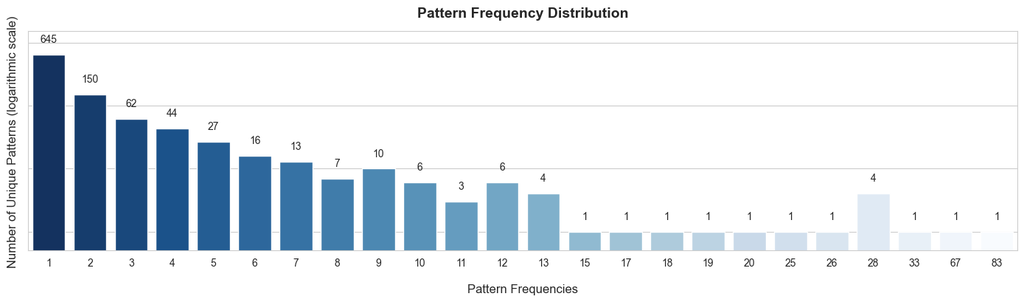

A tabela seguinte apresenta os padrões recorrentes que satisfizeram os critérios de seleção previamente definidos, juntamente com as métricas de desempenho histórico da trajetória de preços subsequente. De acordo com a metodologia adotada neste estudo, vinte e três padrões simbólicos únicos qualificaram-se para análise adicional. Estes padrões ocorreram entre três e cinco vezes ao longo de aproximadamente 46 anos de dados semanais de futuros de Obrigações do Tesouro. As suas relações de retorno/risco a 52 semanas (RR_52_W), calculadas como o rácio entre a mediana da valorização máxima e a desvalorização máxima em valor absoluto, variam aproximadamente entre 0,44 e valores superiores a 10.

| Pattern | Count | MedRunUp_3_W | MedRunUp_10_W | MedRunUp_52_W | MinDrawDown_3_W | MinDrawDown_10_W | MinDrawDown_52_W | TailDrawDown_52_W | MedVol52_W_Rank | RR_52_W |
| --- | --- | --- | --- | --- | --- | --- | --- | --- | --- | --- |
| abcddcab | 3 | 2.937601 | 6.852174 | 22.501400 | -1.382609 | -1.382609 | -2.217391 | -1.869132 | 35.0 | 10.147690 |
| ddbcbaac | 3 | 2.047280 | 3.679621 | 14.175337 | -1.054498 | -1.661068 | -1.661068 | -1.471372 | 8.0 | 8.533871 |
| ddcbbbaa | 3 | 4.217926 | 9.094962 | 19.193045 | -2.010003 | -2.010003 | -2.746060 | -2.231998 | 92.0 | 6.989302 |
| dcdbcaba | 3 | 2.680595 | 4.582635 | 14.089038 | -0.269455 | -2.611940 | -2.611940 | -2.143443 | 77.0 | 5.394089 |
| ddbbaacc | 4 | 1.875666 | 4.565446 | 15.057107 | -2.191923 | -2.191923 | -2.890922 | -2.858293 | 60.5 | 5.208411 |
| cddbcaba | 4 | 1.655411 | 6.392137 | 24.385881 | -2.722689 | -6.256647 | -6.646579 | -5.943362 | 19.0 | 3.668937 |
| dcdcabab | 4 | 2.950820 | 6.803309 | 15.680499 | -2.679006 | -4.540560 | -4.540560 | -4.254865 | 10.5 | 3.453429 |
| baccddba | 3 | 2.005866 | 4.872741 | 10.551342 | -2.938783 | -3.806854 | -3.806854 | -3.494292 | 2.0 | 2.771670 |
| dbbacacd | 3 | 1.651456 | 5.210526 | 13.347477 | -1.173403 | -1.173403 | -6.385965 | -5.343453 | 4.0 | 2.090127 |
| cabacbdd | 3 | 2.407755 | 4.815510 | 10.485720 | -2.607063 | -2.607063 | -5.186318 | -4.217798 | 46.0 | 2.021804 |
| cddbaacb | 5 | 2.082381 | 2.736024 | 15.505431 | -2.636325 | -5.555940 | -8.505777 | -7.325842 | 81.0 | 1.822929 |
| aacddbbc | 4 | 1.877812 | 2.680586 | 9.284515 | -2.111427 | -2.353982 | -6.052655 | -5.298806 | 2.0 | 1.533957 |
| bccaabdd | 4 | 2.200105 | 4.277707 | 10.317460 | -2.494729 | -3.074491 | -6.860341 | -6.338589 | 41.5 | 1.503928 |
| ddcaabbc | 4 | 1.958707 | 4.712201 | 7.996366 | -2.959475 | -3.480747 | -5.784631 | -5.247325 | 72.0 | 1.382347 |
| ddcbabca | 4 | 4.880531 | 6.885473 | 12.389082 | -2.414916 | -4.116845 | -9.220769 | -7.859598 | 98.0 | 1.343606 |
| dcdaabbc | 3 | 0.605857 | 1.544640 | 8.734979 | -1.783911 | -3.391114 | -6.704455 | -6.425292 | 10.0 | 1.302862 |
| bdcdcbaa | 4 | 2.074344 | 2.487765 | 11.455782 | -1.053255 | -4.789116 | -9.940096 | -8.909900 | 18.5 | 1.152482 |
| cddcabba | 3 | 1.329741 | 2.515372 | 5.267902 | -2.235251 | -3.499450 | -4.625489 | -4.512885 | 8.0 | 1.138885 |
| abbdcdca | 3 | 0.668441 | 0.952809 | 10.453933 | -1.862548 | -4.997753 | -9.306250 | -8.573988 | 19.0 | 1.123324 |
| ababdcdc | 3 | 3.503434 | 5.297297 | 6.810811 | -1.069862 | -6.857815 | -7.050390 | -6.472745 | 63.0 | 0.966019 |
| abacbddc | 4 | 1.958915 | 2.034288 | 6.648646 | -2.668317 | -3.636043 | -7.360339 | -6.990488 | 19.0 | 0.903307 |
| bbdcdcaa | 4 | 1.850438 | 2.086270 | 6.510851 | -1.040508 | -4.840903 | -8.690531 | -7.928718 | 24.0 | 0.749189 |
| aabbcbdd | 3 | 3.423299 | 3.423299 | 4.349800 | -0.535779 | -0.914029 | -9.820119 | -9.689328 | 4.0 | 0.442948 |

Para avaliar se os padrões qualificados identificados apresentam um desempenho futuro superior ao que seria expectável com base numa entrada aleatória no mercado, foi realizado um teste de Monte Carlo. As ocorrências históricas dos padrões qualificados foram comparadas com pontos de entrada no mercado selecionados aleatoriamente e com amostras de igual dimensão. Para cada simulação, foi calculada a mediana da valorização máxima a 52 semanas, gerando uma distribuição empírica nula que representa o desempenho esperado sob um cenário de entrada aleatória.

A mediana da valorização máxima a 52 semanas após as ocorrências dos padrões qualificados foi de 11,43%, em comparação com o valor de 8,15% sob entrada aleatória no mercado. Com base em 50 000 simulações de Monte Carlo, a probabilidade de obter uma mediana de valorização igual ou superior à observada para os padrões qualificados sob a hipótese nula foi de 0,27% (p = 0,0027). Este resultado indica que o desempenho histórico associado aos padrões qualificados dificilmente terá surgido apenas por entrada aleatória no mercado.

|  | Value |
| --- | --- |
| Occurrences of qualified patterns | 81 |
| Observed median RunUp_52_W | 11,43% |
| Random median RunUp_52_W | 8,15% |
| Monte Carlo p-value | 0.0027 |

Um segundo teste de Monte Carlo foi realizado para avaliar as características de desvalorização dos padrões qualificados em comparação com entradas aleatórias no mercado. Tal como na análise anterior, posições longas hipotéticas iniciadas nas ocorrências históricas dos padrões qualificados foram comparadas com pontos de entrada selecionados aleatoriamente e com amostras de igual dimensão. Para cada simulação, foi calculada a mediana da desvalorização máxima a 52 semanas, gerando uma distribuição empírica nula para a desvalorização esperada sob entrada aleatória.

A mediana da desvalorização máxima a 52 semanas após as ocorrências dos padrões qualificados foi de -3,47%, em comparação com -5,60% sob entrada aleatória no mercado. Com base em 50 000 simulações de Monte Carlo, a probabilidade de obter uma mediana de desvalorização não superior do que a observada para os padrões qualificados sob a hipótese nula foi de aproximadamente 0,07% (p ≈ 0,0007). Estes resultados sugerem que os padrões qualificados estiveram historicamente associados não apenas a um maior potencial de valorização, mas também a características de desvalorização significativamente mais favoráveis do que seria expectável em entradas aleatórias no mercado.

|  | Value |
| --- | --- |
| Occurrences of qualified patterns | 81 |
| Observed median DrawDown_52_W | -3,47% |
| Random median DrawDown_52_W | -5,60% |
| Monte Carlo p-value | 0.0007 |

O gráfico de dispersão abaixo mostra o desempenho histórico de todos os padrões, medido pela sua valorização máxima mediana e pela desvalorização máxima (minimum drawdown). Os padrões qualificados e não qualificados são distinguidos por cor. A linha vertical tracejada assinala o limiar de desvalorização a 52 semanas de -10%.

Os padrões com desvalorização máxima positiva correspondem a casos em que o preço nunca caiu abaixo do nível de referência dentro da janela de 52 semanas após a ocorrência do padrão. Por outro lado, padrões com valorização máxima mediana negativa representam casos em que o preço se manteve abaixo do nível de referência ao longo das 52 semanas subsequentes.

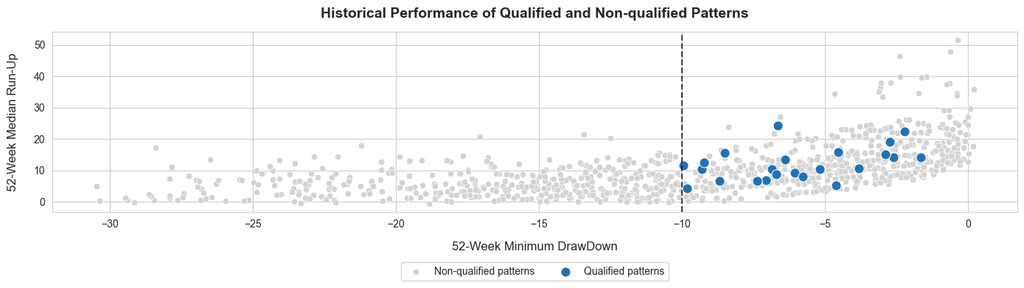

O gráfico seguinte mostra o histórico da ocorrência dos padrões qualificados sobreposto ao preço de fecho semanal dos futuros de Obrigações do Tesouro dos EUA desde a sua criação. Os pontos vermelhos assinalam o momento em que cada padrão qualificado ocorreu.

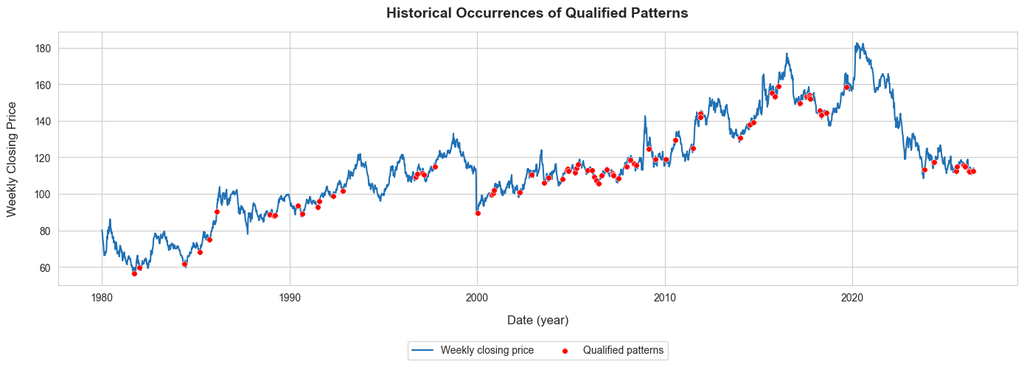

O gráfico de ocorrências históricas sugere que, apesar da recorrência relativamente baixa de padrões simbólicos (SAX) idênticos, os mercados financeiros tendem a reproduzir estruturas de preços semelhantes em fases importantes do mercado, particularmente em inversões importantes de tendências descendentes e na conclusão de movimentos de correção no decorrer de tendências ascendentes estabelecidas. De acordo com os critérios de seleção previamente definidos, a maioria dos padrões qualificados é observada nestas regiões da evolução histórica dos preços.

Embora as estruturas de preços identificadas não sejam idênticas, como evidenciado pelo facto de diferentes padrões simbólicos serem detetados em torno de fases de mercado semelhantes, estas apresentam semelhança estrutural suficiente para se repetirem ao longo do conjunto histórico e exibirem comportamentos de preços subsequentes comparáveis.

Uma observação igualmente importante é o facto de os padrões qualificados associados a importantes inversões de tendência descendente não ocorrerem em condições de mercado substancialmente diferentes. Em vez de surgirem indiscriminadamente ao longo da amostra de dados históricos, estes padrões mantiveram-se concentrados em torno de fases de mercado semelhantes. Esta conclusão aborda o segundo objetivo do estudo, demonstrando que as estruturas de preços recorrentes não estão distribuídas uniformemente ao longo da amostra de dados históricos, mas tendem, pelo contrário, a surgir durante fases de mercado semelhantes. De uma perspetiva prática, esta característica melhora consideravelmente a interpretação e a potencial utilidade dos padrões identificados.

Estes resultados sugerem que certas fases de mercado podem ser caracterizadas por estruturas de preços recorrentes, identificáveis através de representações simbólicas de séries temporais e que podem conter informação útil relativamente ao comportamento subsequente do mercado.

# Implementação Prática

Como poderia a metodologia proposta ser aplicada na prática? Uma possível aplicação consiste na sua integração num sistema automatizado de negociação. Outra aplicação, talvez mais flexível, consiste na sua utilização como ferramenta de apoio à decisão ou de alerta de mercado. Uma vez que o desenvolvimento de uma estratégia de negociação está fora do âmbito deste estudo, esta secção foca-se na segunda abordagem.

O gráfico seguinte ilustra um conceito simples de implementação. Para o padrão qualificado mais recentemente detetado, a evolução histórica dos preços que precede cada uma das suas ocorrências anteriores é apresentada utilizando as 52 semanas anteriores de preços de cotações semanais. Isto permite ao analista ou gestor de carteiras comparar visualmente a configuração atual do mercado com o histórico das ocorrências e avaliar o grau de semelhança estrutural.

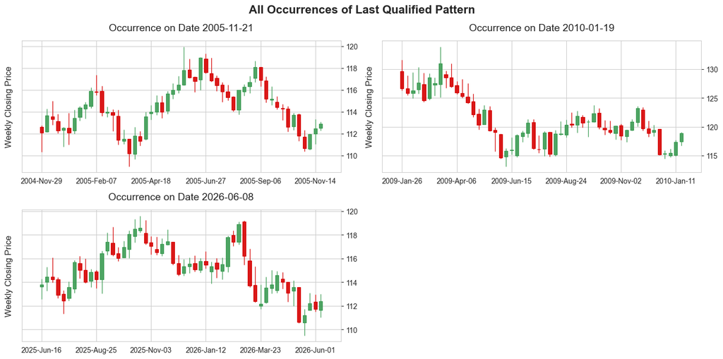

A visualização pode ser complementada com informação de contexto adicional, como o regime de volatilidade prevalecente, medidas de tendência de longo prazo ou outros indicadores de mercado relevantes para o processo de investimento. De forma semelhante, a extensão de cada subgráfico para incluir as semanas subsequentes ao histórico de ocorrência do padrão permitiria analisar a evolução posterior do mercado associada a cada ocorrência. O objetivo desta ferramenta não é automatizar decisões de investimento, mas sim fornecer contexto histórico que possa apoiar a gestão discricionária ou sistemática de carteiras.

Outra aplicação potencial consiste em estender a metodologia a um universo alargado de instrumentos financeiros e integrar os resultados num sistema de filtragem de vários ativos. Um sistema deste tipo poderia reportar, para cada ativo, a data da ocorrência mais recente de um padrão qualificado, juntamente com o seu número histórico de ocorrências, características de relação retorno/risco, métricas do regime de mercado vigente e o desempenho histórico das cotações após ocorrências anteriores. Isto permitiria aos investidores identificar de forma eficiente ativos que apresentam atualmente estruturas de preços historicamente favoráveis e priorizá-los para análise adicional.

# Discussão

Os resultados deste estudo sugerem que o Symbolic Aggregate Approximation (SAX) fornece um enquadramento prático para a identificação de estruturas de preços recorrentes em séries temporais financeiras. Embora a grande maioria dos padrões simbólicos tenha ocorrido apenas uma ou duas vezes ao longo de mais de quatro décadas de dados semanais de futuros de Obrigações do Tesouro, um subconjunto relativamente pequeno repetiu-se com frequência suficiente para permitir avaliação estatística. Entre estes padrões recorrentes, vários apresentaram características historicamente favoráveis em termos de relação retorno/risco, com trajetórias de preços subsequentes que se compararam favoravelmente com pontos de entrada selecionados aleatoriamente no mercado.

Uma observação importante é que os padrões qualificados não se distribuíram de forma uniforme ao longo da série histórica de preços, tendo surgido predominantemente em torno de inversões importantes de tendências descendentes e na conclusão de fases de correção no decorrer de tendências ascendentes de médio e longo prazo. Este resultado é consistente com os critérios de seleção previamente definidos, concebidos para identificar padrões recorrentes historicamente associados a características favoráveis de retorno/risco. Isto sugere que a representação simbólica é capaz de captar características estruturais associadas a fases específicas do mercado, em vez de simplesmente identificar movimentos de preço isolados.

Os testes de Monte Carlo reforçam esta observação. As ocorrências dos padrões qualificados estiveram associadas não apenas a valorizações máximas medianas a 52 semanas significativamente superiores, mas também a desvalorizações máximas medianas significativamente inferiores às observadas em entradas aleatórias no mercado. Embora estes resultados não estabeleçam poder de previsão, indicam que os padrões identificados apresentam características históricas que dificilmente terão surgido apenas por acaso sob a hipótese de entrada aleatória no mercado.

O estudo também evidencia a complexidade dos mercados financeiros. Foram identificados mais de mil padrões simbólicos únicos a partir de aproximadamente 2400 observações semanais, ilustrando a natureza altamente diversa da evolução histórica dos preços. Consequentemente, trajetórias de preços idênticas são relativamente raras, e os padrões recorrentes representam apenas uma pequena fração do total de estados simbólicos. Ainda assim, a recorrência de um número limitado de padrões historicamente favoráveis sugere que os mercados financeiros podem regressar a configurações estruturais semelhantes, apesar das diferenças substanciais ao longo do tempo em termos de contextos macroeconómicos, regimes de política monetária e participantes de mercado.

Devem ser reconhecidas várias limitações. A análise foi realizada sobre um único instrumento financeiro, utilizando parâmetros SAX fixos selecionados durante a fase exploratória. Embora os padrões identificados tenham demonstrado características históricas favoráveis, o número de ocorrências de cada padrão individual permanece relativamente reduzido. Além disso, o estudo avalia associações históricas e não desempenho de previsão, pelo que os padrões identificados devem ser interpretados como estados de mercado e não como sinais de negociação. Trabalhos futuros deverão investigar a robustez da metodologia em diferentes classes de ativos, representações simbólicas alternativas, configurações paramétricas distintas e testes genuinamente fora da amostra.

# Conclusões

Este estudo investigou a aplicação do Symbolic Aggregate Approximation (SAX) na identificação de padrões recorrentes de preços em dados semanais de futuros de Obrigações do Tesouro ao longo de mais de quatro décadas. Através da transformação de janelas deslizantes de observações de preços normalizados em representações simbólicas, foi possível identificar configurações recorrentes de mercado e avaliar o seu comportamento histórico subsequente.

Os resultados indicam que, embora a maioria dos padrões simbólicos ocorra apenas uma ou poucas vezes ao longo da amostra histórica, um subconjunto limitado repete-se com frequência suficiente para apresentar características estatisticamente diferenciadas em termos de relação retorno/risco. Os padrões qualificados estiveram historicamente associados a valorizações subsequentes mais fortes e a desvalorizações mais reduzidas do que pontos de entrada selecionados aleatoriamente no mercado, conforme demonstrado pelos testes de Monte Carlo.

A metodologia apresentada neste estudo não deve ser interpretada como um modelo de previsão nem como um sistema de negociação. Em vez disso, fornece um enquadramento sistemático para identificar configurações de mercado historicamente recorrentes que podem conter informação útil sobre o comportamento subsequente dos preços. Os padrões identificados são inerentemente probabilísticos e devem, por isso, ser considerados em conjunto com outras fontes complementares de informação de mercado e práticas sólidas de gestão de risco.

Por fim, o estudo demonstra que as representações simbólicas de séries temporais financeiras constituem uma alternativa promissora às abordagens quantitativas tradicionais baseadas exclusivamente em rentabilidades, indicadores técnicos ou momentos estatísticos. Ao focar-se na evolução geométrica dos preços em vez dos seus níveis absolutos, o SAX oferece uma representação compacta e interpretável, capaz de revelar características estruturais recorrentes que, de outro modo, poderiam ser difíceis de identificar.

Investigações futuras poderão alargar a metodologia proposta a outras classes de ativos, explorar representações simbólicas alternativas e diferentes configurações de janelas, incorporar indicadores de mercado complementares como regimes de volatilidade e medidas de tendência, e avaliar a robustez dos padrões identificados através de análises genuinamente fora da amostra e prospetivas.

Como nota final, a metodologia proposta não visa prever o futuro, mas sim reconhecer quando o mercado está a exibir uma estrutura de preços que historicamente esteve associada a comportamentos subsequentes semelhantes.

### **Declaração de Exclusão de Responsabilidade**

Este estudo é disponibilizado exclusivamente para fins educativos e de investigação. As análises, metodologias e resultados aqui apresentados destinam-se a ilustrar a aplicação da análise simbólica de séries temporais a dados históricos de mercados financeiros e não devem ser interpretados como aconselhamento de investimento, recomendações de negociação ou garantias de desempenho futuro.

Todos os resultados são baseados em observações históricas e estão sujeitos às limitações inerentes à investigação financeira empírica. O comportamento passado do mercado não garante resultados futuros, e os mercados financeiros são influenciados por vários fatores que não podem ser totalmente captados apenas por padrões históricos de preços.

A metodologia apresentada neste relatório destina-se a apoiar a investigação quantitativa e a análise de investimentos, e não a substituir o julgamento independente, uma avaliação abrangente do mercado ou práticas adequadas de gestão de risco. Qualquer decisão de investimento tomada com base nos conceitos discutidos neste estudo é da inteira responsabilidade do leitor.